# Linear_Regression_on_Advertisement_data slides

## Machine Learning:

### Linear regression on Advertisement data

### Mrinal Sarkar

### 1. Introduction

### 2. Problem Definition

### 3. Solution using Python

#### A. Importing Libraries

#### B. Importing Data

### 4. Data Statistics

### 5. Data Visualization

### 6. Linear Regression

### 6. Linear Regression: Statsmodel Prediction

### 7. Hypothesis test and p-values

### 8. Linear Regression: Scikit-learn Prediction

### 8. RMSE, MSE, R-squared calculation

### 9. Categorical Features with Two Categories¶¶

### 10. Conclusion

## Introduction

Linear regression is one type of supervised learning model where there is a linear relationship between the independent and dependent variable. It predicts a continuous response depending on the history of the initial data. Here, we use linear regression on a given Advertisement dataset to study how the money spent on advertisement impacts sales.

## Problem Definition

Given a dataset which contains the amount of money spent on advertisement and the sales of a widget. By analyzing the dataset, we want to address how one (any company which manufactures this widget) should spend advertising money in the future?

## Solution using Python:

### Importing Libraries:

```python
import pandas as pd
import matplotlib.pyplot as plt
import pandas as pd
import numpy as np
```

### Importing Data

```python
data=pd.read_csv("https://raw.githubusercontent.com/justmarkham/scikit-learn-videos/master/data/Advertising.csv",index_col=0)
```

### Data Statistics

```python
data.head()
```

[output not shown]

```python
data.tail()
```

|  | Unnamed: 0 | TV | Radio | Newspaper | Sales |
| --- | --- | --- | --- | --- | --- |
| 195 | 196 | 38.2 | 3.7 | 13.8 | 7.6 |
| 196 | 197 | 94.2 | 4.9 | 8.1 | 9.7 |
| 197 | 198 | 177.0 | 9.3 | 6.4 | 12.8 |
| 198 | 199 | 283.6 | 42.0 | 66.2 | 25.5 |
| 199 | 200 | 232.1 | 8.6 | 8.7 | 13.4 |

```python
data.shape
```

```
(200, 5)
```

```python
data.describe()
```

|  | Unnamed: 0 | TV | Radio | Newspaper | Sales |
| --- | --- | --- | --- | --- | --- |
| count | 200.000000 | 200.000000 | 200.000000 | 200.000000 | 200.000000 |
| mean | 100.500000 | 147.042500 | 23.264000 | 30.554000 | 14.022500 |
| std | 57.879185 | 85.854236 | 14.846809 | 21.778621 | 5.217457 |
| min | 1.000000 | 0.700000 | 0.000000 | 0.300000 | 1.600000 |
| 25% | 50.750000 | 74.375000 | 9.975000 | 12.750000 | 10.375000 |
| 50% | 100.500000 | 149.750000 | 22.900000 | 25.750000 | 12.900000 |
| 75% | 150.250000 | 218.825000 | 36.525000 | 45.100000 | 17.400000 |
| max | 200.000000 | 296.400000 | 49.600000 | 114.000000 | 27.000000 |

### Features and Response

The features are the following:

1. TV: advertising dollars spent on TV for a single product in a given market (in thousands of dollars)
2. Radio: advertising dollars spent on Radio
3. Newspaper: advertising dollars spent on Newspaper

The response:

1. Sales: sales of a single product in a given market (in thousands of items)

## Visualizing data using seaborn

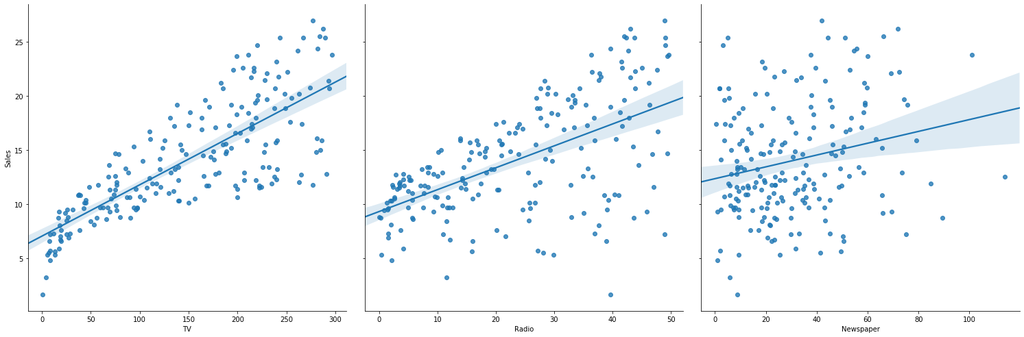

```python
import seaborn as sns
sns.pairplot(data, x_vars=['TV','Radio','Newspaper'], y_vars='Sales', height=7, aspect=1.0, kind='reg')
```

## Linear regression

```python
#To create a Python list of feature names
feature_cols = ['TV', 'Radio', 'Newspaper']

X = data[feature_cols]
#X = data[['TV', 'Radio', 'Newspaper']]
X.head()
```

|  | TV | Radio | Newspaper |
| --- | --- | --- | --- |
| 0 | 230.1 | 37.8 | 69.2 |
| 1 | 44.5 | 39.3 | 45.1 |
| 2 | 17.2 | 45.9 | 69.3 |
| 3 | 151.5 | 41.3 | 58.5 |
| 4 | 180.8 | 10.8 | 58.4 |

```python
print(type(X))
```

```
<class 'pandas.core.frame.DataFrame'>
```

```python
print(X.shape)
```

```
(200, 3)
```

```python
# select a Series from the DataFrame
y = data['Sales']
#y = data.Sales
y.head()
```

```
0    22.1
1    10.4
2     9.3
3    18.5
4    12.9
Name: Sales, dtype: float64
```

```python
print(type(y))
```

```
<class 'pandas.core.series.Series'>
```

```python
# check the type and shape of y
y.shape
```

```
(200,)
```

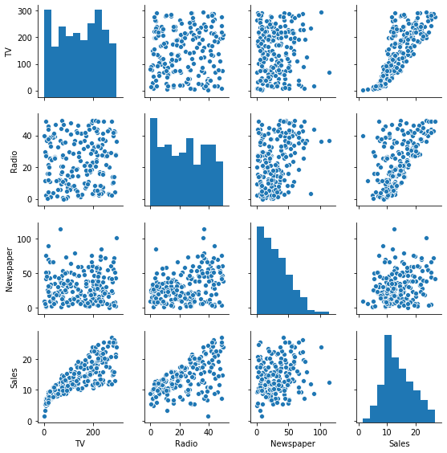

```python
sns.pairplot(data[["TV","Radio","Newspaper","Sales"]],size=2.0)
```

## Statsmodel prediction

```python
### STATSMODELS ###
import statsmodels.formula.api as smf
# create a fitted model with all three features
lm1 = smf.ols(formula='Sales ~ TV + Radio + Newspaper', data=data).fit()

# print the coefficients
lm1.params
```

```
Intercept    2.938889
TV           0.045765
Radio        0.188530
Newspaper   -0.001037
dtype: float64
```

### Confidence in our Model

```python
# print the confidence intervals for the model coefficients
lm1.conf_int()
```

|  | 0 | 1 |
| --- | --- | --- |
| Intercept | 2.323762 | 3.554016 |
| TV | 0.043014 | 0.048516 |
| Radio | 0.171547 | 0.205513 |
| Newspaper | -0.012616 | 0.010541 |

So the confidence interval for Newspaper includes zero only, others don't.

### Hypothesis test and p-values

```python
lm1.summary()
```

OLS Regression Results

| Dep. Variable: | Sales | R-squared: | 0.897 |
| --- | --- | --- | --- |
| Model: | OLS | Adj. R-squared: | 0.896 |
| Method: | Least Squares | F-statistic: | 570.3 |
| Date: | Sun, 13 Oct 2019 | Prob (F-statistic): | 1.58e-96 |
| Time: | 20:18:38 | Log-Likelihood: | -386.18 |
| No. Observations: | 200 | AIC: | 780.4 |
| Df Residuals: | 196 | BIC: | 793.6 |
| Df Model: | 3 |  |  |
| Covariance Type: | nonrobust |  |  |

|  | coef | std err | t | P>\|t\| | [0.025 | 0.975] |
| --- | --- | --- | --- | --- | --- | --- |
| Intercept | 2.9389 | 0.312 | 9.422 | 0.000 | 2.324 | 3.554 |
| TV | 0.0458 | 0.001 | 32.809 | 0.000 | 0.043 | 0.049 |
| Radio | 0.1885 | 0.009 | 21.893 | 0.000 | 0.172 | 0.206 |
| Newspaper | -0.0010 | 0.006 | -0.177 | 0.860 | -0.013 | 0.011 |

| Omnibus: | 60.414 | Durbin-Watson: | 2.084 |
| --- | --- | --- | --- |
| Prob(Omnibus): | 0.000 | Jarque-Bera (JB): | 151.241 |
| Skew: | -1.327 | Prob(JB): | 1.44e-33 |
| Kurtosis: | 6.332 | Cond. No. | 454. |

Warnings:  
[1] Standard Errors assume that the covariance matrix of the errors is correctly specified.

```python
lm1.pvalues
```

```
Intercept    1.267295e-17
TV           1.509960e-81
Radio        1.505339e-54
Newspaper    8.599151e-01
dtype: float64
```

#### Interpretation:

As we observed, the confidence interval for Newspaper includes zero only, others don't. The p-values for TV and radio are approximately zero, where for Newspaper it is approximately 0.86.

The conventional Null Hypothesis is:

```
  There is no relationship between the features and the response.
```

Alternative Hypothesis:

```
  There is a relationship between the features and the response.
```

From the above 95% Confidence interval data and p-values, we note the following:

```
           1. For TV and Radio ads, the Confidence interval does not include zero and p-value is approximately zero (<0.05)
           2. For Newspaper ads, the Confidence interval include zero and the p-value is approximately 0.86.
```

## Sci-kit learn prediction

## To split X and y into training and testing sets

```python
from sklearn.model_selection import train_test_split
X_train, X_test, y_train, y_test = train_test_split(X, y, test_size=0.33, random_state=50)
print(X_train.shape)
print(y_train.shape)
print(X_test.shape)
print(y_test.shape)
```

```
(134, 3)
(134,)
(66, 3)
(66,)
```

## Linear regression in scikit-learn

```python
# import model
from sklearn.linear_model import LinearRegression
# instantiate
linreg = LinearRegression()
# fit the model to the training data (learn the coefficients)
linreg.fit(X_train, y_train)
```

```
LinearRegression(copy_X=True, fit_intercept=True, n_jobs=None, normalize=False)
```

### Interpreting model coefficients

```python
# print the intercept and coefficients
print(linreg.intercept_)
print(linreg.coef_)
```

```
2.6464412205750953
[0.04792526 0.18118227 0.00604156]
```

```python
# print coefficients corresponding to features
list(zip(feature_cols, linreg.coef_))
```

```
[('TV', 0.04792526295723654),
 ('Radio', 0.18118226805368576),
 ('Newspaper', 0.006041564693445967)]
```

```python
# make predictions on the testing set
y_pred = linreg.predict(X_test)
```

## Computing the RMSE, MSE, R_squared for Sales predictions

```python
from sklearn.metrics import mean_squared_error, r2_score,mean_absolute_error
mean_abs_error=mean_absolute_error(y_test,y_pred)
Mean_squared_error=mean_squared_error(y_test,y_pred)
RMSE=np.sqrt(metrics.mean_squared_error(y_test, y_pred))
R_square=r2_score(y_test,y_pred)
```

```python
mean_abs_error
```

```
1.2295712397123406
```

```python
R_square
```

```
0.8582882277585369
```

```python
RMSE,Mean_squared_error
```

```
(1.6223689867762163, 2.6320811292532866)
```

## Comparison between actual and predicted values

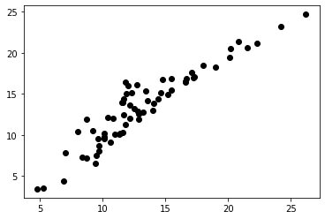

```python
plt.scatter(y_test, y_pred, color='black')
```

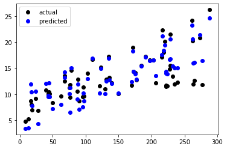

```python
plt.plot(X_test['TV'], y_test,'o', color='black',label='actual')
plt.plot(X_test['TV'], y_pred,'o', color='blue',label='predicted')
plt.legend()
```

## Categorical Features with Two Categories¶

So far what we have studied the datasets where all the features are numeric. Sometimes few features may be categorical too. In such a case, how would we apply Linear Regression technique?

For example, we create a new feature called Size, and randomly assign observations to be small or large:

```python
# set a seed for reproducibility
np.random.seed(58411)

# For two categories, we can assign each of them with an equal probability (0.5)
# create a Series of booleans in which roughly half are True
nums = np.random.rand(len(data))
mask_large = nums > 0.5

# initially set Size to small, then change roughly half to be large
data['Size'] = 'small'

# Series.loc is a purely label-location based indexer for selection by label
data.loc[mask_large, 'Size'] = 'large'
data.head()
```

|  | Unnamed: 0 | TV | Radio | Newspaper | Sales | Size |
| --- | --- | --- | --- | --- | --- | --- |
| 0 | 1 | 230.1 | 37.8 | 69.2 | 22.1 | small |
| 1 | 2 | 44.5 | 39.3 | 45.1 | 10.4 | large |
| 2 | 3 | 17.2 | 45.9 | 69.3 | 9.3 | small |
| 3 | 4 | 151.5 | 41.3 | 58.5 | 18.5 | large |
| 4 | 5 | 180.8 | 10.8 | 58.4 | 12.9 | small |

Now we can't work with this categorical data in scikit-learn, we need to map it to numerical values. The feature having two categories only, we use binary dummy variable to represent it : small=0 and large=1.

```python
# create a new Series called Size_large
data['Size_large'] = data.Size.map({'small':0, 'large':1})
data.head()
```

|  | Unnamed: 0 | TV | Radio | Newspaper | Sales | Size | Size_large |
| --- | --- | --- | --- | --- | --- | --- | --- |
| 0 | 1 | 230.1 | 37.8 | 69.2 | 22.1 | small | 0 |
| 1 | 2 | 44.5 | 39.3 | 45.1 | 10.4 | large | 1 |
| 2 | 3 | 17.2 | 45.9 | 69.3 | 9.3 | small | 0 |
| 3 | 4 | 151.5 | 41.3 | 58.5 | 18.5 | large | 1 |
| 4 | 5 | 180.8 | 10.8 | 58.4 | 12.9 | small | 0 |

Now we can do Linear regression as before including the new added feature "Size_large".

```python
#To create a Python list of feature names including the new one
feature_cols = ['TV', 'Radio', 'Newspaper', 'Size_large']

# use the list to select a subset of the original DataFrame
X = data[feature_cols]

X.head()
```

|  | TV | Radio | Newspaper | Size_large |
| --- | --- | --- | --- | --- |
| 0 | 230.1 | 37.8 | 69.2 | 0 |
| 1 | 44.5 | 39.3 | 45.1 | 1 |
| 2 | 17.2 | 45.9 | 69.3 | 0 |
| 3 | 151.5 | 41.3 | 58.5 | 1 |
| 4 | 180.8 | 10.8 | 58.4 | 0 |

```python
y = data['Sales']
```

```python
y.head()
```

```
0    22.1
1    10.4
2     9.3
3    18.5
4    12.9
Name: Sales, dtype: float64
```

```python
# check the type and shape of y
print(type(y))
print(y.shape)
```

```
<class 'pandas.core.series.Series'>
(200,)
```

```python
from sklearn.model_selection import train_test_split
X_train, X_test, y_train, y_test = train_test_split(X, y, test_size=0.33, random_state=50)
print(X_train.shape)
print(y_train.shape)
print(X_test.shape)
print(y_test.shape)
```

[output not shown]

```python
# instantiate
linreg_new = LinearRegression()
# fit the model to the training data (learn the coefficients)
linreg_new.fit(X_train, y_train)
```

```
LinearRegression(copy_X=True, fit_intercept=True, n_jobs=None, normalize=False)
```

### Interpreting new model coefficients

```python
# print the intercept and coefficients
print(linreg_new.intercept_)
print(linreg_new.coef_)
```

[output not shown]

```python
# print coefficients corresponding to features
list(zip(feature_cols, linreg_new.coef_))
```

[output not shown]

```python
# make predictions on the testing set
y_pred = linreg_new.predict(X_test)
#y_pred
```

```python
from sklearn.metrics import mean_absolute_error, mean_squared_error, r2_score
Mean_absolute_error=mean_absolute_error(y_test,y_pred)
Mean_squared_error=mean_squared_error(y_test,y_pred)
R_square=r2_score(y_test,y_pred)
```

```python
Mean_absolute_error,Mean_squared_error,R_square
```

[output not shown]

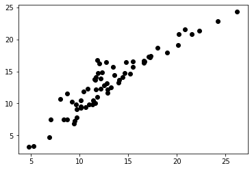

```python
plt.scatter(y_test, y_pred, color='black')
```

Here, we study one example of how to deal with categorial feature with two levels only. That's why we created one dummy binary variable. We can extend the idea to a categorical feature with any no of levels. In general, for a categorical feature with k "levels", we need to create k-1 dummy variables.

## Conclusion:

1. We study linear regression on the Advertisement datasets available to us. We observe that there is a liear dependency of the TV add and Radio ad on sales of the widget.
2. We study how to apply the linear regression model even if there are Categorical Features.